# Analysis

Qiuiqing Ge

2/24/2022

### Introduction

The reason for the report was to tackle the problem of racism. According to the news, racism affects the prison population, so I decided to investigate the prison population to see what the reality is.

I want to mention again that this file mainly focus about **the rate of people of color in jail** which only including AAPI, Black, Latinx, Native American race and **the rate of white people in the jail** is mentioned in this report as well.There are also several graphs to compared the relationship between these two variables: `the rate of people of color in jail` and `the rate of white people in the jail`.

As for the data frame I made, it is from **1990** to **2018**. By analyzing this data frame I found that the highest color rate is **0.69** in **1993**. As for minimum rate of white rate is in **1990**. According to the data found above, it seems that in the 1990s there were more people of color in prison and fewer white people in prison. This seems to indicate a relationship between the two: people of color are more likely to be imprisoned as a result of racial discrimination. **But is this the case?**

Below is a **chart of the people of color jailing**. Throughout the years the trend over time.

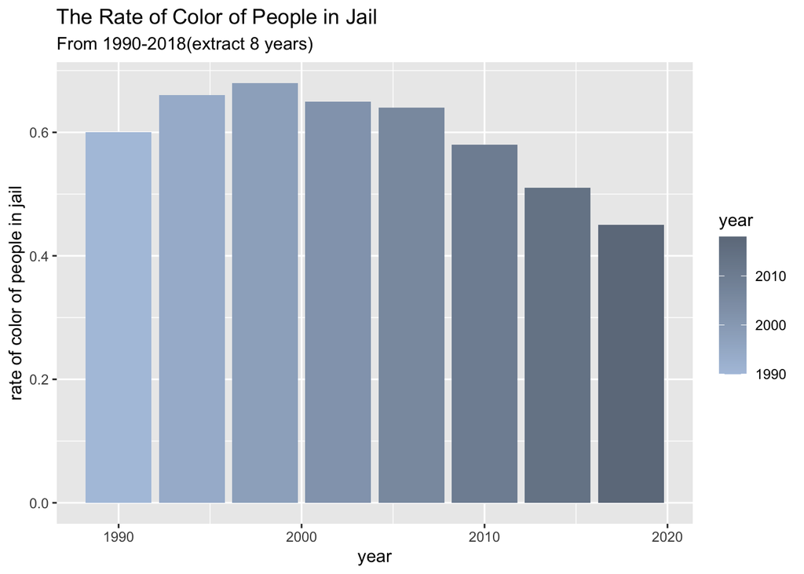

###### Reminder: The rates of people of color are already multipied by 100, which are stands for percentages.

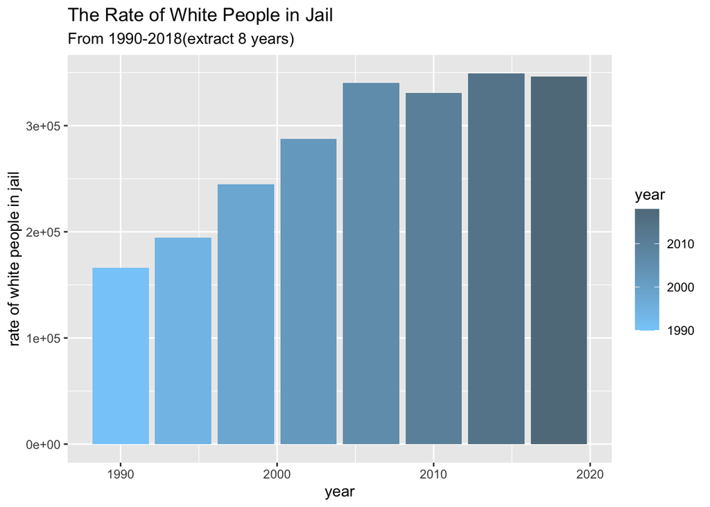

###### Reminder: The rates of people of color are already multipied by 100, which are stands for percentages.

The above two figures all represent the change trend of a variable year by year, but cannot represent the relationship between the two variables.

The following diagram can clearly shows **the relationship between the two variables and year**

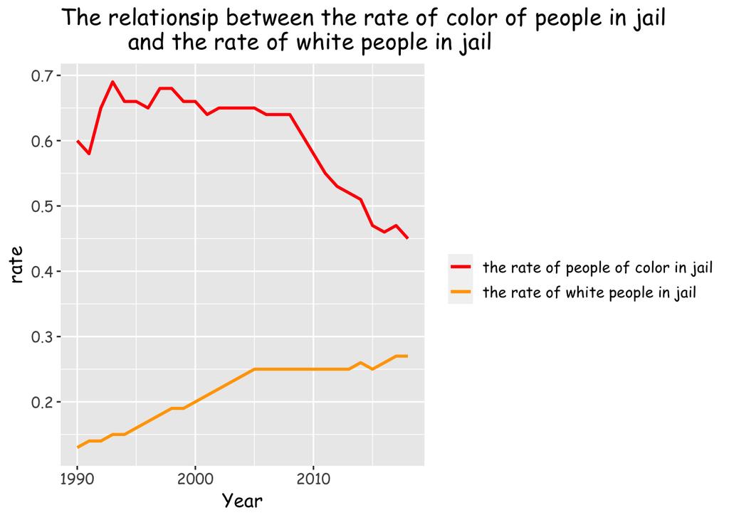

###### Reminder: The rates of people of color are already multipied by 100, which are stands for percentages.

Here is also a graph talking about the relationship between two variables talked before.

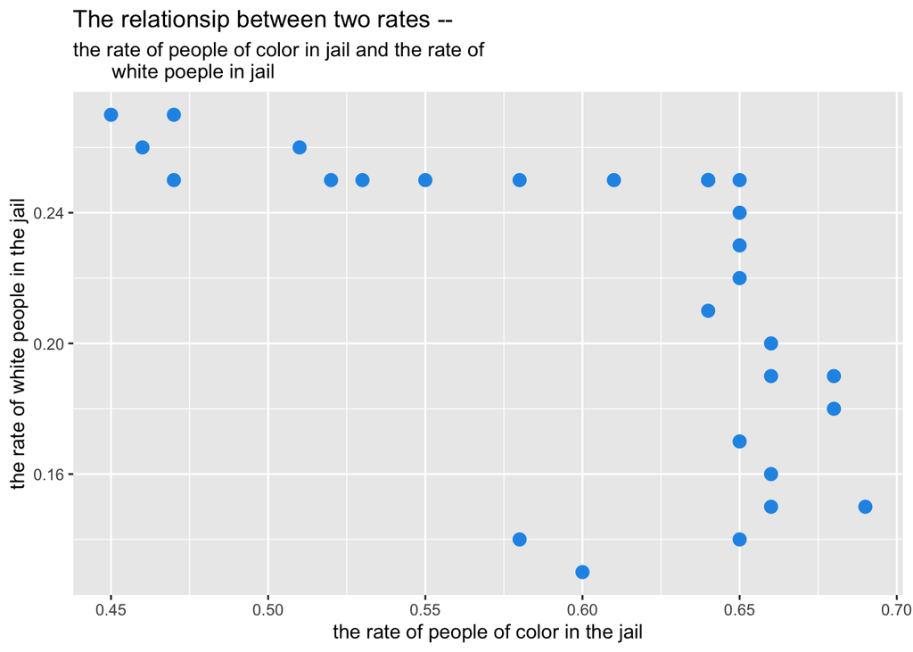

###### Reminder: The rates of people of color are already multipied by 100, which are stands for percentages.

The reason why I am **interested** in this plot is that I can analyze the relationship between these two variables `the rate of people of color in jail` and `the rate of white in jail`. Here is my predication. This chart illustrates the relationship between the two variables. It can be found that when the rate of colored people in prison is lower than 0.65%, the rate of white people in prison does not fluctuate greatly, but when the rate of colored people in prison is higher than 0.65%, the rate of white people in prison decreases rapidly. From the above data, it can be concluded that racial discrimination does affect the number of people going to prison, but it also improves or does not. Because if racial discrimination continues to affect the prison population, then this graph shows that white people are in prison at a very low rate and people of color at a very high rate.

I also have a plot to talk about the relationship between the state and the people of color in different states. In this plot, I just **distract top 10 states** which has the higher `rate of people of color in jail` compared to the rest of states.

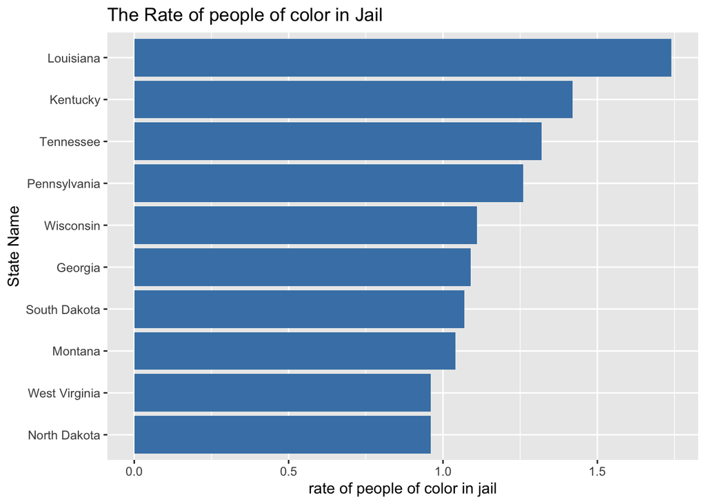

The reason why I am so **curious** about this chart is that I want to know which state are most influence by the effect about the racial discrimination. In other words, I want to know the states have what kind of characteristic will influenced by the racial discrimination. The chart above tell me that the most of state which most influence by the effect of the racial discrimination are located in the middle of state. *Most of states in the above chart are places for farming or place for having lots of heavy industries.* I think the reason why these place influenced by racial discrimination is that these places has lots of slaves in the 19th century.

Below is a map of the United States showing the people of color’s jail population in every state.

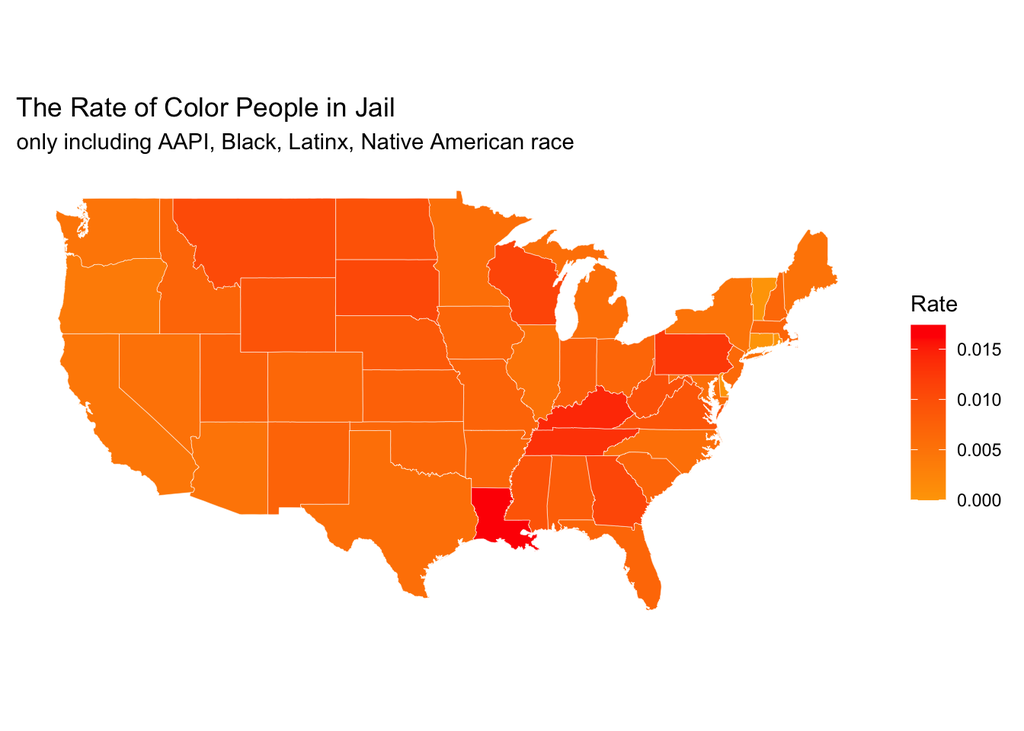

### Summary

After studying the data, these images actually surprised me, and I thought the rate of this colored person going to prison would be very high because of the influence of racial discrimination. But in fact, the effect is not very big, in other words, the effect of racial discrimination is actually there, but people are gradually reducing the prejudice.

### **limitaion** for this data

- The data provided by this assignment lacks the data of the total population of some races, such as: total population of black people, total population of Latinx, people, total population of native American people, total population of aapi people and total population of white. Specifically, since this data only includes the total number of individuals of each of the six ethnic groups aged 15-64, the number given is only the number of individuals of each of the six ethnic groups, so it is not accurate to calculate the percentage of individuals in prison in this case. But another research conclusion provided by the “codebook” from data set is that youth under age 15 and adults over 64 are age groups at very low risk of jail incarceration so I deduce that the population of the different race people who under 15 or over 64 does not influence the result completely. These value are also meaningful.
- The second the limitation of this file is that the people of color I explored is only AAPI, Black, Latinx, Native American race. Because this data frame lacks the total data of other race in total(even no data about the other race aged from 15-64), it is impossible to calculate the rate by using `other race in jail` dividing by `other race in total` in order to get the rate.